# Mapping host density in the conterminous United States using the CroplandCROS database

Aaron I. Plex Sulá

2024-01-25

The purpose of this vignette is to show how crop distribution from the CroplandCROS (https://croplandcros.scinet.usda.gov/) database can be used to map cropland density in the continental United States. CroplandCROS is an extensive, publicly available database maintained by the USDA and provides information of the spatial distribution of many crops in the United States since 1997.

**Note**: Before using this database, a good practice is to check the accuracy of estimated crop distribution you are interested to work with. Accuracy in this database is crop- and state-specific. The user should decide which accuracy threshold is acceptable.

## Unique example

In the link provided above, the user download the data specifying the following criteria:

1. First choose the crop, area of interest (AOI) and year. Our example here illustrates the case of citrus in Florida in 2022.
2. Then, export a GeoTIFF file making sure to use Web Mercator (WGS 84) as the coordinate reference system (crs) and select DPI = 96 as the resolution. **Note**: if you choose other crs in your download, the code below may be modified.
3. Check that you get a compressed (zipped) folder with all information including (but not only) the .tif file called “clipped”. **Note**: At the time of the creation of this vignette (January 24th, 2024), selecting other DPI values did not download the correct GeoTIFF file.
4. Finally, generate the host density map as follows.

```r
# Install require package
library(terra)
```

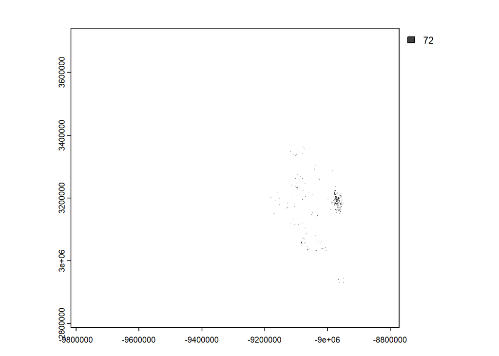

```r
# Read your GeoTIFF file and plot the map
citrus<-rast("clipped.tif")
plot(citrus, col = "grey25")
```

```r
citrus
```

```
## class       : SpatRaster
## dimensions  : 31762, 34844, 1  (nrow, ncol, nlyr)
## resolution  : 30, 30  (x, y)
## extent      : -9816805, -8771485, 2787932, 3740792  (xmin, xmax, ymin, ymax)
## coord. ref. : WGS 84 / Pseudo-Mercator (EPSG:3857)
## source      : clipped.TIF
## name        : clipped
## min value   :      72
## max value   :      72
```

When calling the `citrus` above, this indicates that `citrus` is an object of class SpatRaster and the unique values in each cell (pixel or location) are 72. Each cell measures 30 m by 30 m (see resolution).

We now replace the code for citrus (i.e., 72) with 1 to define where the crop is present. Note that the code for each crop is different, so it is useful plotting the map or calling the SpatRaster object to identify this code.

```r
# Replacing crop code with 1 in each cell that citrus is reported present
v<-72
citrus<-citrus/v
```

```
##
|---------|---------|---------|---------|
=========================================
```

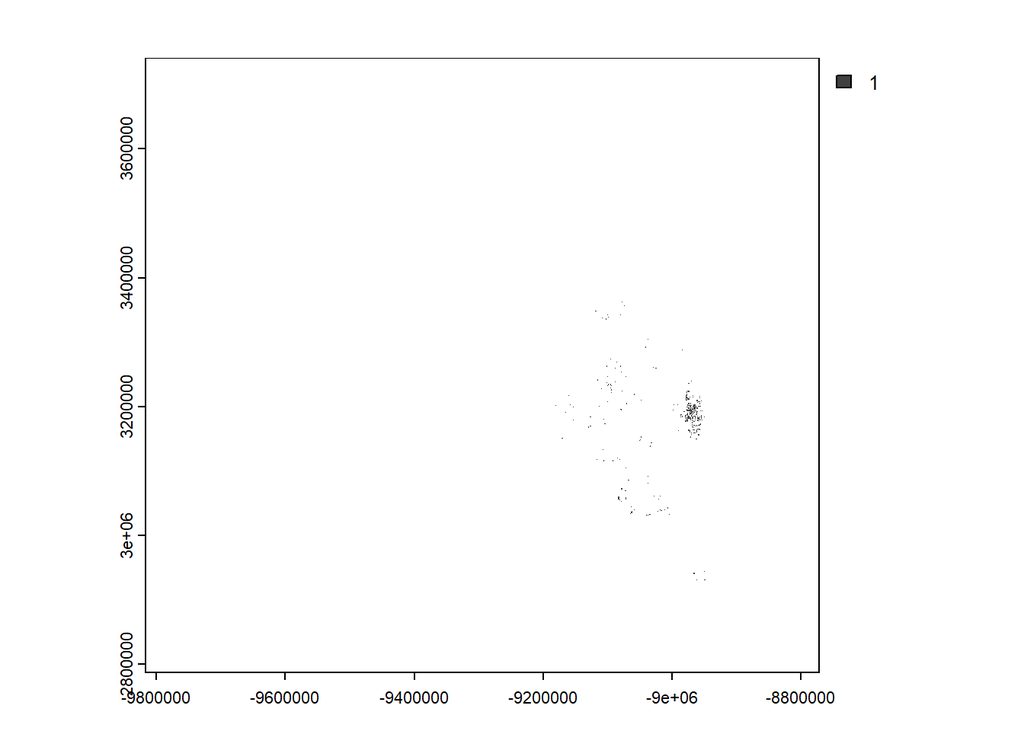

```r
plot(citrus, col = "grey25")
```

Finally, let’s transform our presence-only map into a host density map.

```r
# Assigning a different crs or geographic projection.
citrus<-project(citrus, "+proj=longlat +datum=WGS84")
```

```
##
|---------|---------|---------|---------|
=========================================
```

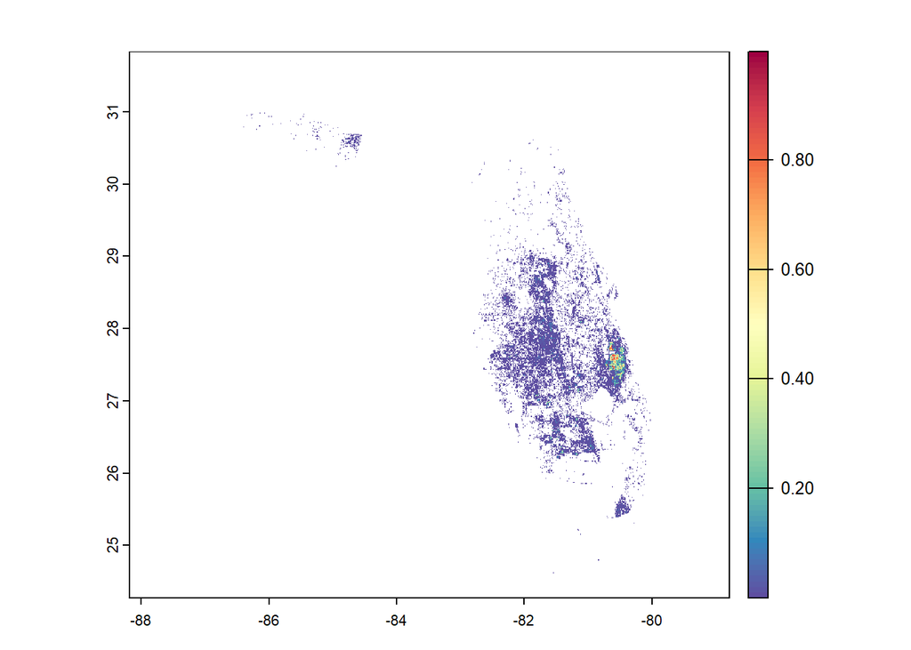

```r
# Aggregating small cells into larger cells to calculate host density
aggregation.factor<-40
aggregated.citrus<-aggregate(citrus, fact = aggregation.factor,
                             fun = "sum",
                             na.rm = TRUE) / (aggregation.factor*aggregation.factor)

# Visualize the new map of host density
library(RColorBrewer)
color.set <- colorRampPalette(rev(brewer.pal(11, "Spectral")),space="Lab")

plot(aggregated.citrus, col = color.set(100))
```

```r
aggregated.citrus
```

```
## class       : SpatRaster
## dimensions  : 739, 919, 1  (nrow, ncol, nlyr)
## resolution  : 0.01021983, 0.01021983  (x, y)
## extent      : -88.18586, -78.79384, 24.27584, 31.82829  (xmin, xmax, ymin, ymax)
## coord. ref. : +proj=longlat +datum=WGS84 +no_defs
## source(s)   : memory
## name        :  clipped
## min value   : 0.000625
## max value   : 0.997500
```

```r
# Save the host density map
writeRaster(aggregated.citrus, "FloridaCitrus01.tif")
```

- Aggregation factor refers to the number of small cells that will be combined to generate larger cells.

In our example, host density is calculated by summing all values (except non-availables) of 1,600 small cells into a larger cell divided by the total number of cells aggregated. A total of 1,600 small cells comes from 40 cells in the x-axis times 40 cells in the y-axis. This way, host density will range from 0 to 1. For example, if only one cell of the 1,600 small cells had citrus present, then host density in its corresponding larger cell will be 1/1600 = 0.000625.

**Note**: The `project()` and `aggregate()` functions took about 15 minutes the first and 5 minutes the second as the dataset used is at high resolution!

Congratulations! Now you can use this dataset from USDA to calculate host connectivity with the geohabnet package, ;)…